# ReCell

## Problem Statement

### Business Context

Buying and selling used phones and tablets used to be something that happened on a handful of online marketplace sites. But the used and refurbished device market has grown considerably over the past decade, and a new IDC (International Data Corporation) forecast predicts that the used phone market would be worth \$52.7bn by 2023 with a compound annual growth rate (CAGR) of 13.6% from 2018 to 2023. This growth can be attributed to an uptick in demand for used phones and tablets that offer considerable savings compared with new models.

Refurbished and used devices continue to provide cost-effective alternatives to both consumers and businesses that are looking to save money when purchasing one. There are plenty of other benefits associated with the used device market. Used and refurbished devices can be sold with warranties and can also be insured with proof of purchase. Third-party vendors/platforms, such as Verizon, Amazon, etc., provide attractive offers to customers for refurbished devices. Maximizing the longevity of devices through second-hand trade also reduces their environmental impact and helps in recycling and reducing waste. The impact of the COVID-19 outbreak may further boost this segment as consumers cut back on discretionary spending and buy phones and tablets only for immediate needs.

### Objective

The rising potential of this comparatively under-the-radar market fuels the need for an ML-based solution to develop a dynamic pricing strategy for used and refurbished devices. ReCell, a startup aiming to tap the potential in this market, has consulted me as a data scientist. They want me to analyze the data provided and build a linear regression model to predict the price of a used phone/tablet and identify factors that significantly influence it.

### Data Description

The data contains the different attributes of used/refurbished phones and tablets. The data was collected in the year 2021. The detailed data dictionary is given below.

- brand_name: Name of manufacturing brand
- os: OS on which the device runs
- screen_size: Size of the screen in cm
- 4g: Whether 4G is available or not
- 5g: Whether 5G is available or not
- main_camera_mp: Resolution of the rear camera in megapixels
- selfie_camera_mp: Resolution of the front camera in megapixels
- int_memory: Amount of internal memory (ROM) in GB
- ram: Amount of RAM in GB
- battery: Energy capacity of the device battery in mAh
- weight: Weight of the device in grams
- release_year: Year when the device model was released
- days_used: Number of days the used/refurbished device has been used
- normalized_new_price: Normalized price of a new device of the same model in euros
- normalized_used_price: Normalized price of the used/refurbished device in euros

## Importing necessary libraries

```python
# Installing the libraries with the specified version.
# uncomment and run the following line if Google Colab is being used
# !pip install scikit-learn==1.2.2 seaborn==0.13.1 matplotlib==3.7.1 numpy==1.25.2 pandas==1.5.3 -q --user
```

```python
# Installing the libraries with the specified version.
# uncomment and run the following lines if Jupyter Notebook is being used
# !pip install scikit-learn==1.2.2 seaborn==0.11.1 matplotlib==3.3.4 numpy==1.24.3 pandas==1.5.2 -q --user
```

**Note**: *After running the above cell, kindly restart the notebook kernel and run all cells sequentially from the start again.*

```python
# Libraries to help with reading and manipulating data
import numpy as np
import pandas as pd

# Libraries to help with data visualization
import matplotlib.pyplot as plt
import seaborn as sns

sns.set()

# split the data into train and test
from sklearn.model_selection import train_test_split

# to build linear regression_model
from sklearn.linear_model import LinearRegression

# to check model performance
from sklearn.metrics import mean_absolute_error, mean_squared_error, r2_score

# to build linear regression_model using statsmodels
import statsmodels.api as sm

# to compute VIF
from statsmodels.stats.outliers_influence import variance_inflation_factor

import warnings
warnings.simplefilter(action='ignore', category=FutureWarning)
```

## Loading the dataset

```python
# uncomment and run the following lines for Google Colab
from google.colab import drive
drive.mount('/content/drive')
```

```python
# loading data
data = pd.read_csv('/content/drive/MyDrive/content/used_device_data.csv')
```

## Data Overview

**Displaying the first few rows of the dataset**

```python
data.head()
```

|  | brand_name | os | screen_size | 4g | 5g | main_camera_mp | selfie_camera_mp | int_memory | ram | battery | weight | release_year | days_used | normalized_used_price | normalized_new_price |
| --- | --- | --- | --- | --- | --- | --- | --- | --- | --- | --- | --- | --- | --- | --- | --- |
| 0 | Honor | Android | 14.50 | yes | no | 13.0 | 5.0 | 64.0 | 3.0 | 3020.0 | 146.0 | 2020 | 127 | 4.307572 | 4.715100 |
| 1 | Honor | Android | 17.30 | yes | yes | 13.0 | 16.0 | 128.0 | 8.0 | 4300.0 | 213.0 | 2020 | 325 | 5.162097 | 5.519018 |
| 2 | Honor | Android | 16.69 | yes | yes | 13.0 | 8.0 | 128.0 | 8.0 | 4200.0 | 213.0 | 2020 | 162 | 5.111084 | 5.884631 |
| 3 | Honor | Android | 25.50 | yes | yes | 13.0 | 8.0 | 64.0 | 6.0 | 7250.0 | 480.0 | 2020 | 345 | 5.135387 | 5.630961 |
| 4 | Honor | Android | 15.32 | yes | no | 13.0 | 8.0 | 64.0 | 3.0 | 5000.0 | 185.0 | 2020 | 293 | 4.389995 | 4.947837 |

**Displaying the shape of the dataset**

```python
data.shape
```

```
(3454, 15)
```

**Observations**

Total Rows in the DS: **3454**

Total Columns in the DS: **15**

**Data types of the columns for the dataset**

```python
data.info()
```

```
<class 'pandas.core.frame.DataFrame'>
RangeIndex: 3454 entries, 0 to 3453
Data columns (total 15 columns):
 #   Column                 Non-Null Count  Dtype
---  ------                 --------------  -----
 0   brand_name             3454 non-null   object
 1   os                     3454 non-null   object
 2   screen_size            3454 non-null   float64
 3   4g                     3454 non-null   object
 4   5g                     3454 non-null   object
 5   main_camera_mp         3275 non-null   float64
 6   selfie_camera_mp       3452 non-null   float64
 7   int_memory             3450 non-null   float64
 8   ram                    3450 non-null   float64
 9   battery                3448 non-null   float64
 10  weight                 3447 non-null   float64
 11  release_year           3454 non-null   int64
 12  days_used              3454 non-null   int64
 13  normalized_used_price  3454 non-null   float64
 14  normalized_new_price   3454 non-null   float64
dtypes: float64(9), int64(2), object(4)
memory usage: 404.9+ KB
```

**Observations:**

- There are 4 object type columns
- There are 9 float type columns
- There are 2 integer type columns

We should convert Object types to category:

```python
category_col = data.select_dtypes(exclude=np.number).columns.tolist()
data[category_col] = data[category_col].astype("category")
```

```python
data.info()
```

```
<class 'pandas.core.frame.DataFrame'>
RangeIndex: 3454 entries, 0 to 3453
Data columns (total 15 columns):
 #   Column                 Non-Null Count  Dtype
---  ------                 --------------  -----
 0   brand_name             3454 non-null   category
 1   os                     3454 non-null   category
 2   screen_size            3454 non-null   float64
 3   4g                     3454 non-null   category
 4   5g                     3454 non-null   category
 5   main_camera_mp         3275 non-null   float64
 6   selfie_camera_mp       3452 non-null   float64
 7   int_memory             3450 non-null   float64
 8   ram                    3450 non-null   float64
 9   battery                3448 non-null   float64
 10  weight                 3447 non-null   float64
 11  release_year           3454 non-null   int64
 12  days_used              3454 non-null   int64
 13  normalized_used_price  3454 non-null   float64
 14  normalized_new_price   3454 non-null   float64
dtypes: category(4), float64(9), int64(2)
memory usage: 312.2 KB
```

**Statistical summary of the dataset**

```python
data.describe(include='all').T
```

|  | count | unique | top | freq | mean | std | min | 25% | 50% | 75% | max |
| --- | --- | --- | --- | --- | --- | --- | --- | --- | --- | --- | --- |
| brand_name | 3454 | 34 | Others | 502 | NaN | NaN | NaN | NaN | NaN | NaN | NaN |
| os | 3454 | 4 | Android | 3214 | NaN | NaN | NaN | NaN | NaN | NaN | NaN |
| screen_size | 3454.0 | NaN | NaN | NaN | 13.713115 | 3.80528 | 5.08 | 12.7 | 12.83 | 15.34 | 30.71 |
| 4g | 3454 | 2 | yes | 2335 | NaN | NaN | NaN | NaN | NaN | NaN | NaN |
| 5g | 3454 | 2 | no | 3302 | NaN | NaN | NaN | NaN | NaN | NaN | NaN |
| main_camera_mp | 3275.0 | NaN | NaN | NaN | 9.460208 | 4.815461 | 0.08 | 5.0 | 8.0 | 13.0 | 48.0 |
| selfie_camera_mp | 3452.0 | NaN | NaN | NaN | 6.554229 | 6.970372 | 0.0 | 2.0 | 5.0 | 8.0 | 32.0 |
| int_memory | 3450.0 | NaN | NaN | NaN | 54.573099 | 84.972371 | 0.01 | 16.0 | 32.0 | 64.0 | 1024.0 |
| ram | 3450.0 | NaN | NaN | NaN | 4.036122 | 1.365105 | 0.02 | 4.0 | 4.0 | 4.0 | 12.0 |
| battery | 3448.0 | NaN | NaN | NaN | 3133.402697 | 1299.682844 | 500.0 | 2100.0 | 3000.0 | 4000.0 | 9720.0 |
| weight | 3447.0 | NaN | NaN | NaN | 182.751871 | 88.413228 | 69.0 | 142.0 | 160.0 | 185.0 | 855.0 |
| release_year | 3454.0 | NaN | NaN | NaN | 2015.965258 | 2.298455 | 2013.0 | 2014.0 | 2015.5 | 2018.0 | 2020.0 |
| days_used | 3454.0 | NaN | NaN | NaN | 674.869716 | 248.580166 | 91.0 | 533.5 | 690.5 | 868.75 | 1094.0 |
| normalized_used_price | 3454.0 | NaN | NaN | NaN | 4.364712 | 0.588914 | 1.536867 | 4.033931 | 4.405133 | 4.7557 | 6.619433 |
| normalized_new_price | 3454.0 | NaN | NaN | NaN | 5.233107 | 0.683637 | 2.901422 | 4.790342 | 5.245892 | 5.673718 | 7.847841 |

**Observations:**

**Checking for duplicate values**

```python
data.duplicated().sum()
```

```
0
```

There are NO duplicate values in the Dataset

**Checking for missing values**

```python
data.isnull().sum()
```

|  | 0 |
| --- | --- |
| brand_name | 0 |
| os | 0 |
| screen_size | 0 |
| 4g | 0 |
| 5g | 0 |
| main_camera_mp | 179 |
| selfie_camera_mp | 2 |
| int_memory | 4 |
| ram | 4 |
| battery | 6 |
| weight | 7 |
| release_year | 0 |
| days_used | 0 |
| normalized_used_price | 0 |
| normalized_new_price | 0 |

**dtype:** int64

**Observations:** There are missing values in the dataset as follows:

- main camera mp: **179** values not found
- selfie camera mp: **2** values not found
- internal memory: **4** values not found
- ram memory: **4** values not found
- battery: **6** values not found
- weight: **7** values not found

Since missing values were found, down in the process they will be imputed to avoid errors in data calculation.

```python
# creating a copy of the data so that original data is not changed.
df = data.copy()
```

## Exploratory Data Analysis (EDA)

- EDA is an important part of any project involving data.
- It is important to investigate and understand the data better before building a model with it.
- A few questions have been mentioned below which will help you approach the analysis in the right manner and generate insights from the data.
- A thorough analysis of the data, in addition to the questions mentioned below, should be done.

**Questions**:

1. What does the distribution of normalized used device prices look like?
2. What percentage of the used device market is dominated by Android devices?
3. The amount of RAM is important for the smooth functioning of a device. How does the amount of RAM vary with the brand?
4. A large battery often increases a device's weight, making it feel uncomfortable in the hands. How does the weight vary for phones and tablets offering large batteries (more than 4500 mAh)?
5. Bigger screens are desirable for entertainment purposes as they offer a better viewing experience. How many phones and tablets are available across different brands with a screen size larger than 6 inches?
6. A lot of devices nowadays offer great selfie cameras, allowing us to capture our favorite moments with loved ones. What is the distribution of devices offering greater than 8MP selfie cameras across brands?
7. Which attributes are highly correlated with the normalized price of a used device?

### Univariate Analysis

```python
# function to create labeled barplots


def labeled_barplot(data, feature, perc=False, n=None):
    """
    Barplot with percentage at the top

    data: dataframe
    feature: dataframe column
    perc: whether to display percentages instead of count (default is False)
    n: displays the top n category levels (default is None, i.e., display all levels)
    """

    total = len(data[feature])  # length of the column
    count = data[feature].nunique()
    if n is None:
        plt.figure(figsize=(count + 2, 6))
    else:
        plt.figure(figsize=(n + 2, 6))

    plt.xticks(rotation=90, fontsize=15)
    ax = sns.countplot(
        data=data,
        x=feature,
        palette="Paired",
        order=data[feature].value_counts().index[:n],
    )

    for p in ax.patches:
        if perc == True:
            label = "{:.1f}%".format(
                100 * p.get_height() / total
            )  # percentage of each class of the category
        else:
            label = p.get_height()  # count of each level of the category

        x = p.get_x() + p.get_width() / 2  # width of the plot
        y = p.get_height()  # height of the plot

        ax.annotate(
            label,
            (x, y),
            ha="center",
            va="center",
            size=12,
            xytext=(0, 5),
            textcoords="offset points",
        )  # annotate the percentage

    plt.show()  # show the plot
```

#### **`Distribution of normalized_used_price`**

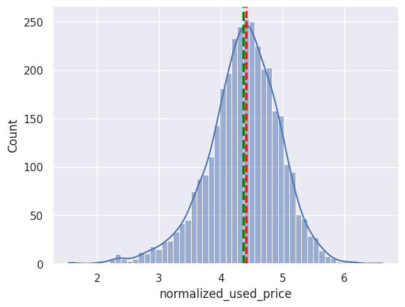

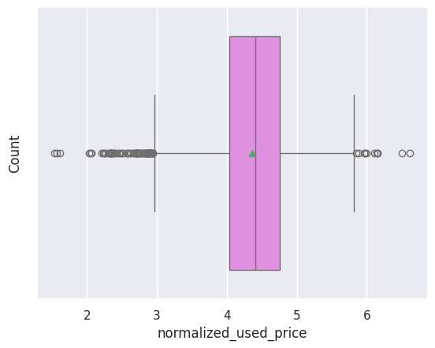

```python
#Histogram
sns.histplot(df, x = 'normalized_used_price', kde=True);
plt.xlabel('normalized_used_price');
plt.axvline(x=df.normalized_used_price.mean(),
            color='green', ls='--',
            lw=2.5)
plt.axvline(x=df.normalized_used_price.median(),
            color='red', ls='--',
            lw=2)
plt.show()

#Boxplot
sns.boxplot(df, x = 'normalized_used_price', showmeans=True, color="violet");
plt.xlabel('normalized_used_price');
plt.ylabel('Count');
plt.show()
```

**Observations:**

- Normalized used price seems to be following a normal distribution with some outliers specially in the lower price.

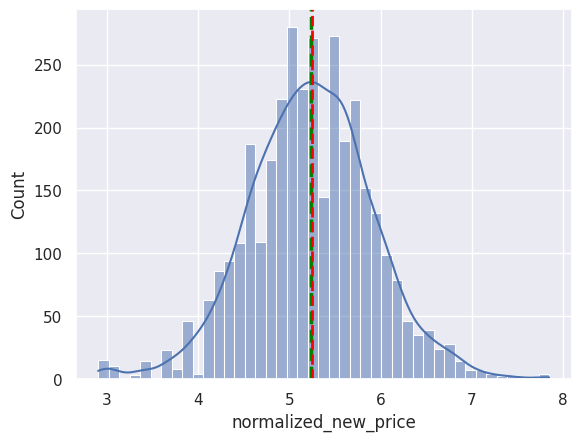

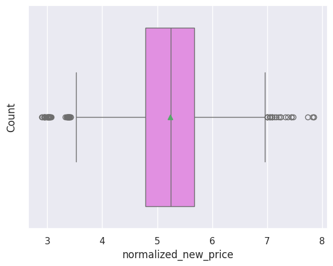

```python
#Histogram
sns.histplot(df, x = 'normalized_new_price', kde=True);
plt.xlabel('normalized_new_price');
plt.axvline(x=df.normalized_new_price.mean(),
            color='green', ls='--',
            lw=2.5)
plt.axvline(x=df.normalized_new_price.median(),
            color='red', ls='--',
            lw=2)
plt.show()

#Boxplot
sns.boxplot(df, x = 'normalized_new_price', showmeans=True, color="violet");
plt.xlabel('normalized_new_price');
plt.ylabel('Count');
plt.show()
```

**Observations:**

- Normalized new price seems to be following a normal distribution with some outliers on both higher and lower prices.

#### **`Distribution of screen_size`**

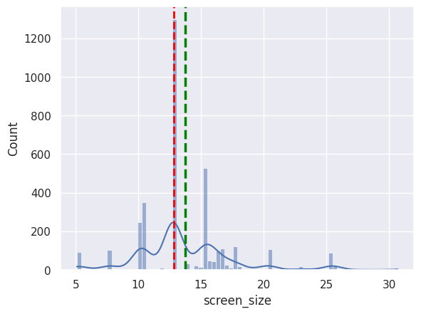

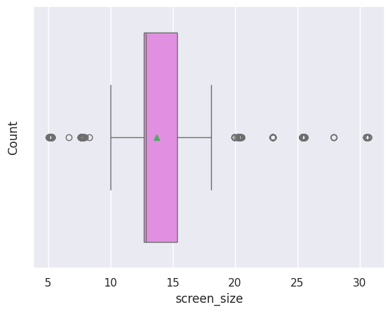

```python
#Histogram
sns.histplot(df, x = 'screen_size', kde=True);
plt.xlabel('screen_size');
plt.axvline(x=df.screen_size.mean(),
            color='green', ls='--',
            lw=2.5)
plt.axvline(x=df.screen_size.median(),
            color='red', ls='--',
            lw=2)
plt.show()

#Boxplot
sns.boxplot(df, x = 'screen_size', showmeans=True, color="violet");
plt.xlabel('screen_size');
plt.ylabel('Count');
plt.show()
```

**Observations:**

- Screen size does not show any specific distribution with outliers found in smaller and larger screen sizes. Data slightly shows a normal distribution but with no clear definition.

#### **`Distribution of main_camera_mp`**

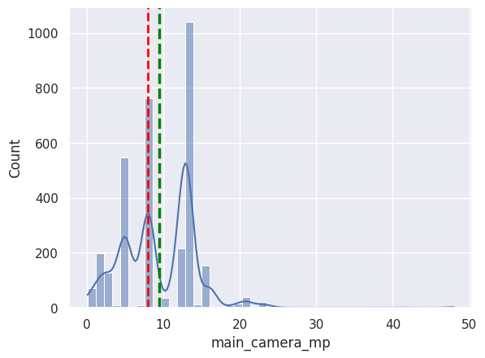

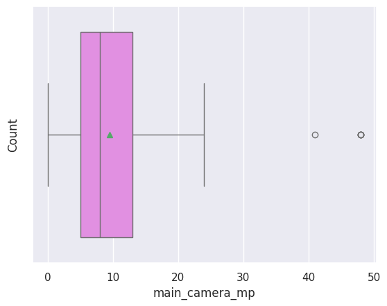

```python
#Histogram
sns.histplot(df, x = 'main_camera_mp', kde=True);
plt.xlabel('main_camera_mp');
plt.axvline(x=df.main_camera_mp.mean(),
            color='green', ls='--',
            lw=2.5)
plt.axvline(x=df.main_camera_mp.median(),
            color='red', ls='--',
            lw=2)
plt.show()

#Boxplot
sns.boxplot(df, x = 'main_camera_mp', showmeans=True, color="violet");
plt.xlabel('main_camera_mp');
plt.ylabel('Count');
plt.show()
```

**Observations:**

#### **`Distribution of selfie_camera_mp`**

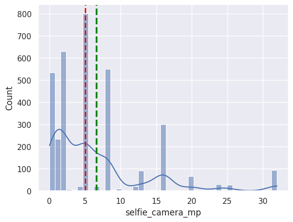

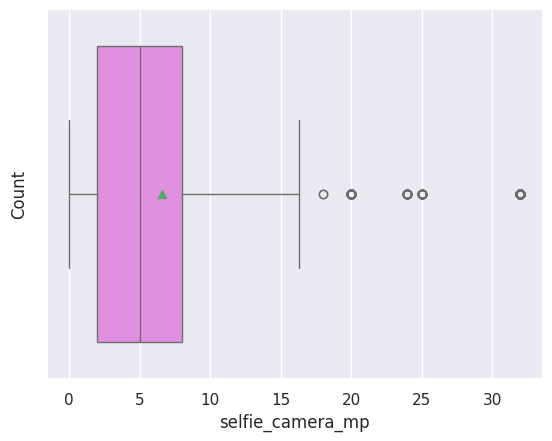

```python
#Histogram
sns.histplot(df, x = 'selfie_camera_mp', kde=True);
plt.xlabel('selfie_camera_mp');
plt.axvline(x=df.selfie_camera_mp.mean(),
            color='green', ls='--',
            lw=2.5)
plt.axvline(x=df.selfie_camera_mp.median(),
            color='red', ls='--',
            lw=2)
plt.show()

#Boxplot
sns.boxplot(df, x = 'selfie_camera_mp', showmeans=True, color="violet");
plt.xlabel('selfie_camera_mp');
plt.ylabel('Count');
plt.show()
```

**Observations:**

- Selfie camera mp shows slightly skewness to the right with outliers on the bigger size.

#### **`Distribution of int_memory`**

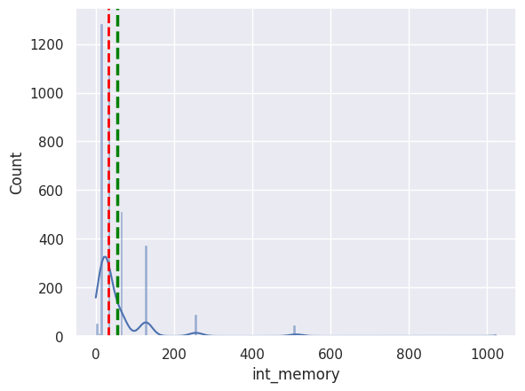

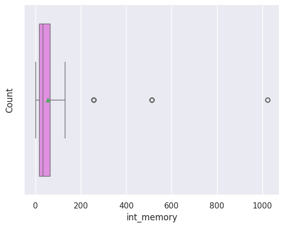

```python
#Histogram
sns.histplot(df, x = 'int_memory', kde=True);
plt.xlabel('int_memory');
plt.axvline(x=df.int_memory.mean(),
            color='green', ls='--',
            lw=2.5)
plt.axvline(x=df.int_memory.median(),
            color='red', ls='--',
            lw=2)
plt.show()

#Boxplot
sns.boxplot(df, x = 'int_memory', showmeans=True, color="violet");
plt.xlabel('int_memory');
plt.ylabel('Count');
plt.show()
```

**Observations:**

- Internal memory seems to be skewed to the right with outliers to the larger end.

#### **`Distribution of ram`**

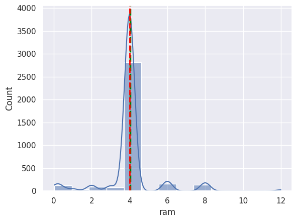

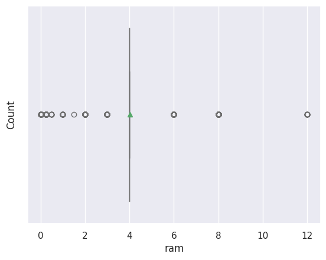

```python
#Histogram
sns.histplot(df, x = 'ram', kde=True);
plt.xlabel('ram');
plt.axvline(x=df.ram.mean(),
            color='green', ls='--',
            lw=2.5)
plt.axvline(x=df.ram.median(),
            color='red', ls='--',
            lw=2)
plt.show()

#Boxplot
sns.boxplot(df, x = 'ram', showmeans=True, color="violet");
plt.xlabel('ram');
plt.ylabel('Count');
plt.show()
```

**Observations:**

- The data does not show any distribution associated to RAM.

#### **`Distribution of weight`**

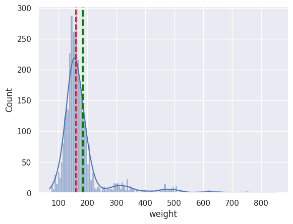

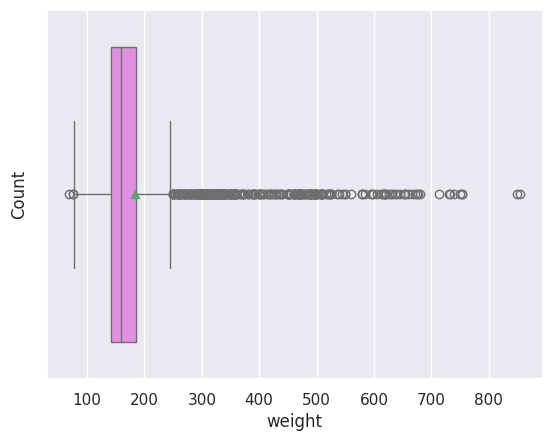

```python
#Histogram
sns.histplot(df, x = 'weight', kde=True);
plt.xlabel('weight');
plt.axvline(x=df.weight.mean(),
            color='green', ls='--',
            lw=2.5)
plt.axvline(x=df.weight.median(),
            color='red', ls='--',
            lw=2)
plt.show()

#Boxplot
sns.boxplot(df, x = 'weight', showmeans=True, color="violet");
plt.xlabel('weight');
plt.ylabel('Count');
plt.show()
```

**Observations:**

- The weight of devices appears to be slightly skewed to the right with outliers heavily present to the heavier side.

#### **`Distribution of battery`**

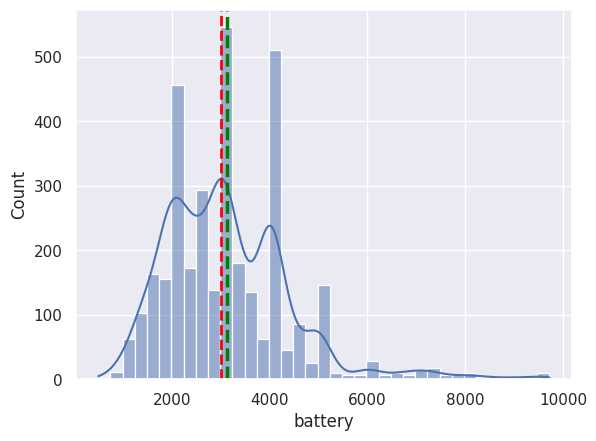

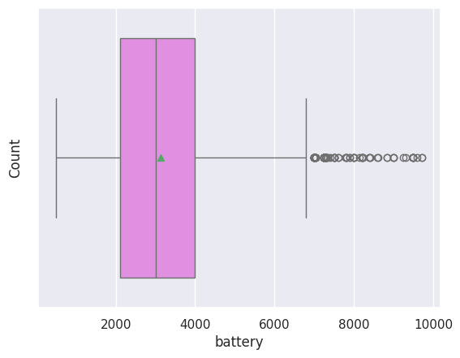

```python
#Histogram
sns.histplot(df, x = 'battery', kde=True);
plt.xlabel('battery');
plt.axvline(x=df.battery.mean(),
            color='green', ls='--',
            lw=2.5)
plt.axvline(x=df.battery.median(),
            color='red', ls='--',
            lw=2)
plt.show()

#Boxplot
sns.boxplot(df, x = 'battery', showmeans=True, color="violet");
plt.xlabel('battery');
plt.ylabel('Count');
plt.show()
```

**Observations:**

- The battery capacity shows a multimodal distribution with some outliers on the larger end.

#### **`Distribution of days_used`**

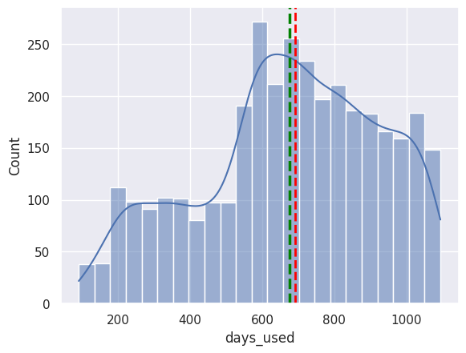

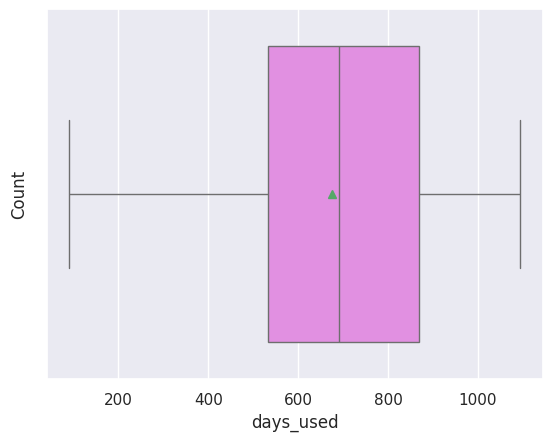

```python
#Histogram
sns.histplot(df, x = 'days_used', kde=True);
plt.xlabel('days_used');
plt.axvline(x=df.days_used.mean(),
            color='green', ls='--',
            lw=2.5)
plt.axvline(x=df.days_used.median(),
            color='red', ls='--',
            lw=2)
plt.show()

#Boxplot
sns.boxplot(df, x = 'days_used', showmeans=True, color="violet");
plt.xlabel('days_used');
plt.ylabel('Count');
plt.show()
```

**Observations:**

- The days that the devices are used presents a distribution slightly skewed to the left with no outliers.

#### **`Distribution of brand_name`**

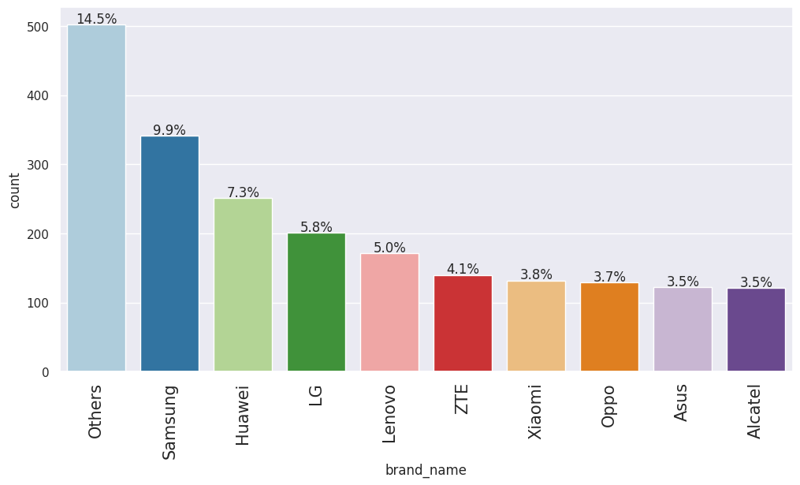

```python
labeled_barplot(df, "brand_name", perc=True, n=10)
```

**Observations:**

- Multiple brands represented in the data as "Others" are the most commonly used among users with 14.5% of the total.
- Samsung, Huawei and LG take second, third and fourth place in popularity among owners with 9.9%, 7.3% and 5.8% respectively.

#### **`Distribution of os`**

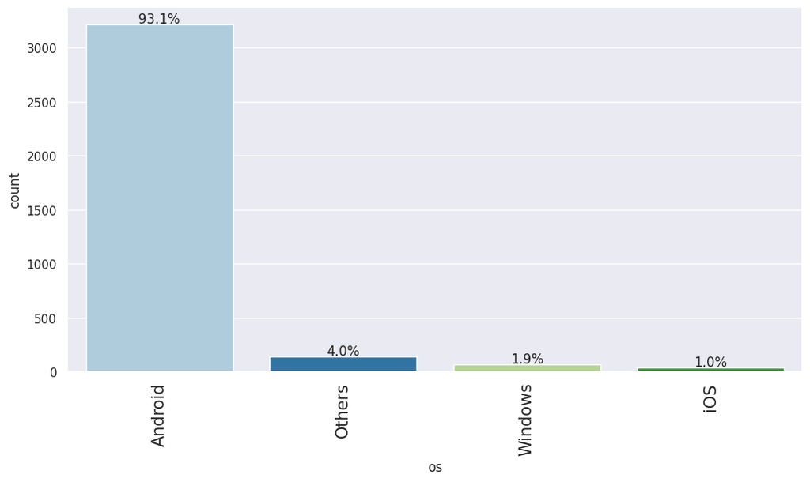

```python
labeled_barplot(df,'os', perc=True, n=10)
```

**Observations:**

- Android is by far the most common operative system selected among users with 93.1% of the total devices.
- iOS represents only 1% and it is the smallest. Other systems grouped together are present in 4% of the devices.

#### **`Distribution of 4G`**

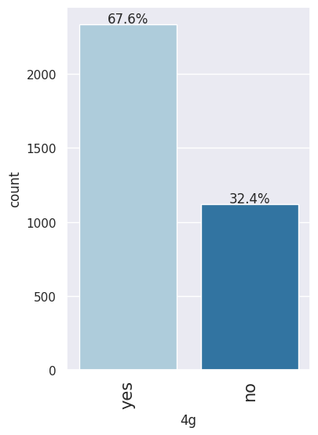

```python
labeled_barplot(df,'4g', perc=True)
```

**Observations:**

- The majority of devices run in 4g with a total of 67.6%.

#### **`Distribution of 5G`**

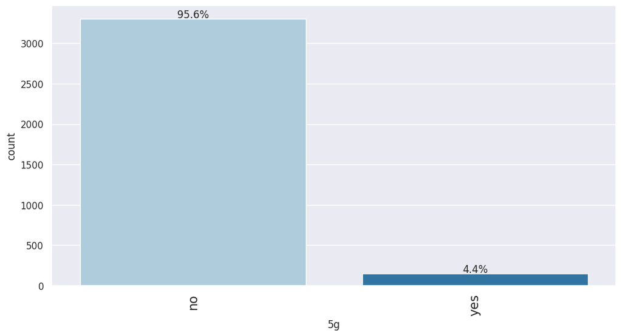

```python
labeled_barplot(df,'5g', perc=True, n=10)
```

**Observations:**

- Just 4.4% of devices are 5g enabled. The extensive majority of mobiles represented as 95.6% out of the total, do not support 5g

#### **`Distribution of release_year`**

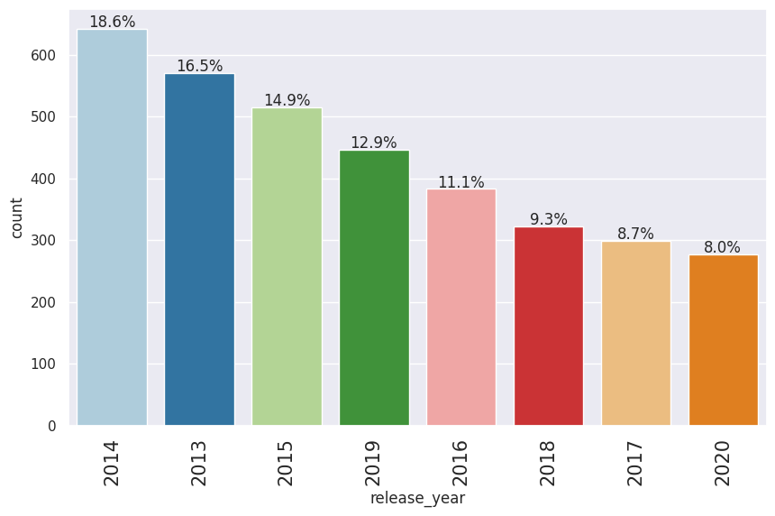

```python
labeled_barplot(df,'release_year', perc=True)
```

**Observations:**

- 2014 is the most common year of release with a total of 18.6% of devices.
- 2013 and 2015 are the second and third most found with 16.5% and 14.9% respectively.
- Most recent years like 2020 or 2019 are not that common among users with only 8% and 12.9% of preference respectively.

### Bivariate Analysis

#### **Correlation Check**

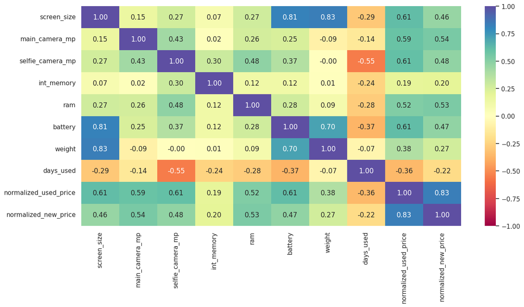

```python
cols_list = df.select_dtypes(include=np.number).columns.tolist()
# dropping release_year as it is a temporal variable
cols_list.remove("release_year")

plt.figure(figsize=(15, 7))
sns.heatmap(
    df[cols_list].corr(), annot=True, vmin=-1, vmax=1, fmt=".2f", cmap="Spectral"
)
plt.show()
```

**Observations:**

- Normalized price of used devices is highly positively correlated with the priced normalized of new devices.
- Screen size is highly positively correlated with the battery and weight.
- Battery capacity is positively correlated with the the weight.
- The normalized price of the devices is negatively correlated with the number of days the device has been used.

#### **RAM accross brands**

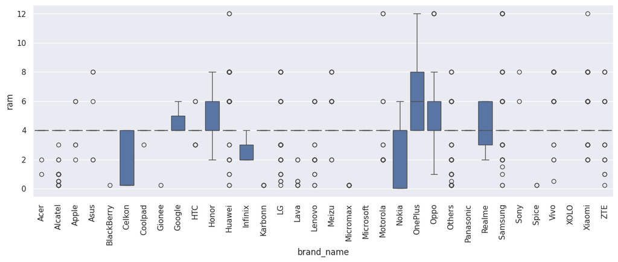

```python
plt.figure(figsize=(15, 5))
sns.boxplot(data=df, x="brand_name", y="ram")
plt.xticks(rotation=90)
plt.show()
```

**Observations:**

#### **Weight/Battery correlation accross brands with batteries above 4500 mAh**

```python
#Subsetting batteries larger than 4500 mAh
df_large_battery = df[df.battery > 4500]
df_large_battery.shape
```

```
(341, 15)
```

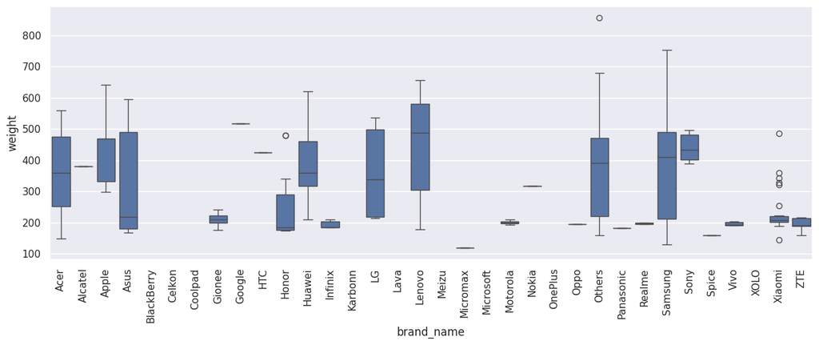

```python
plt.figure(figsize=(15, 5))
sns.boxplot(df_large_battery, x='brand_name', y='weight')
plt.xticks(rotation=90)
plt.show()
```

**Observations:**

- Weight varies from each brand with no particular distribution.
- Samsung seems to have more options than other brands in the weight of its devices.
- All google devices seems to weight almost the same and there are no big variations in it.
- Micromax has the lightest devices.

#### **Devices available with screens bigger than 6 inches**

```python
df_large_screen = df[df.screen_size > 6 * 2.54]
df_large_screen.shape
```

```
(1099, 15)
```

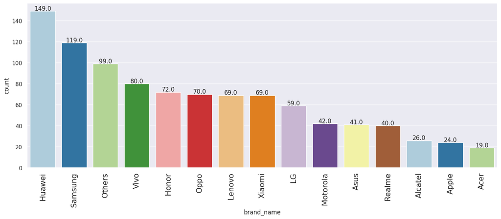

```python
labeled_barplot(df_large_screen, 'brand_name', n=15)
```

**Observations:**

#### **Devices available with selfie cameras bigger than 8 MP**

```python
df_selfie_camera = df[df.selfie_camera_mp > 8]
df_selfie_camera.shape
```

```
(655, 15)
```

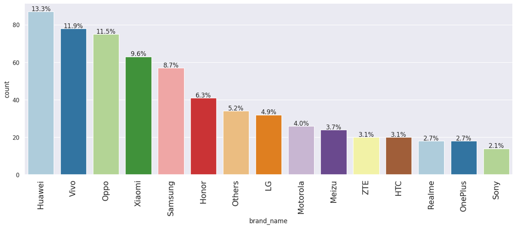

```python
labeled_barplot(df_selfie_camera, 'brand_name', n=15, perc=True)
```

**Observations:**

- Huawei once again comes first in relation with the capacity of their front facing cameras representing 13.3% out of the total.
- Vivo and Oppo come second and third respectively with 11.9% and 11.5% of the total.

#### **Devices available with back cameras bigger than *16* MP**

```python
df_main_camera = df[df.main_camera_mp > 16]
df_main_camera.shape
```

```
(94, 15)
```

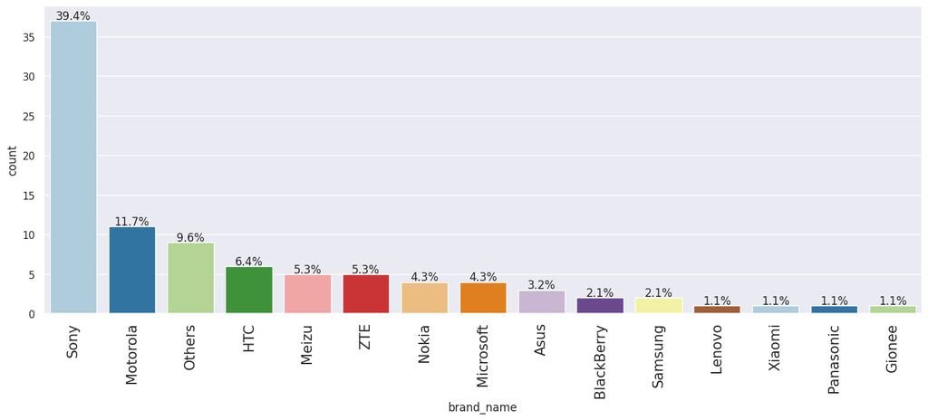

```python
labeled_barplot(df_main_camera, 'brand_name', n=15, perc=True)
```

**Observations:**